# Supplementary Figures

### Increased pollination generalization does not necessarily result in relaxed evolutionary constraints on corolla shape

Simon Joly, François Lambert, Hermine Alexandre, Julien Clavel, Étienne Léveillé-Bourret, John L. Clark

*Submitted to The American Naturalist*

## Supplementary Figure 1

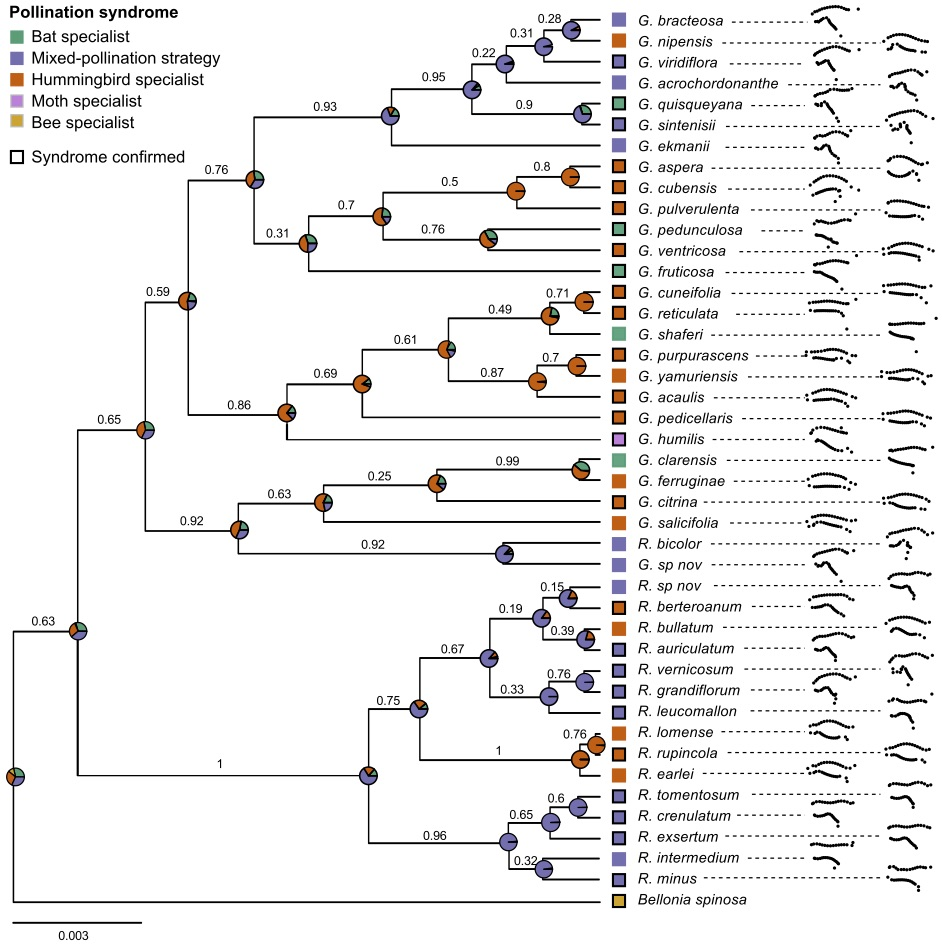

## Supplementary Figure 2

Principal component analysis showing the corolla shape morphospace for all individuals. Pollination syndromes are shown by different colours. The large dots on the plot represent the species means and the individual floral shapes (small dots) are associated with their species mean by gray lines. Place your cursor over the points to get species and specimen information. You can also zoom in the figure.

[interactive chart not shown]

## Supplementary Figure 3

Principal component analysis showing the corolla shape morphospace for the individuals excluding the hummingbird pollinated species. Pollination syndromes are shown by different colours. The large dots on the plot represent the species means and the individual floral shapes (small dots) are associated with their species mean by gray lines. Place your cursor over the points to get species and specimen information. You can also zoom in the figure.

[interactive chart not shown]

## Supplementary Figure 4

Akaike ($AICc$) weights for the multivariate evolutionary models when all species are included in the analyses (syndromes are inferred from the corolla shape for unknown).

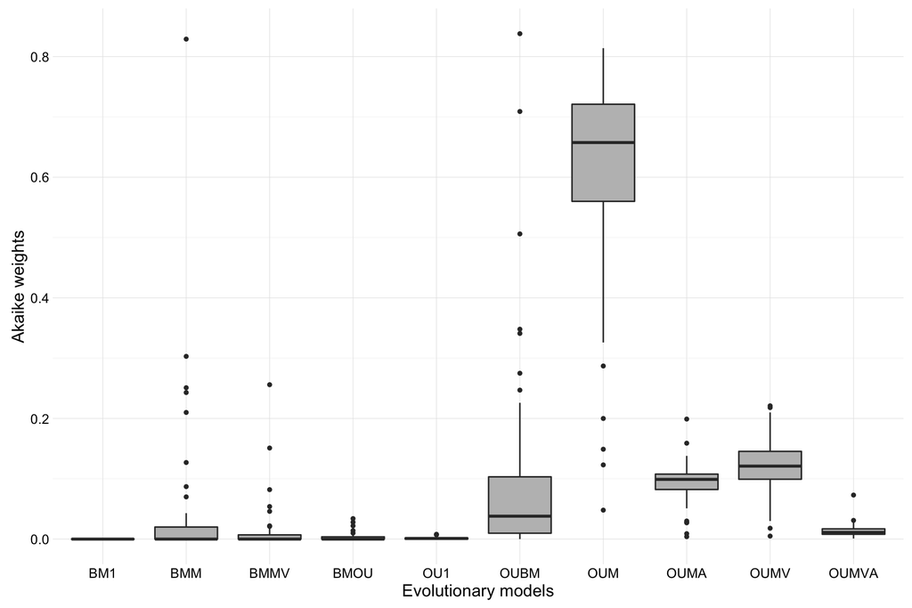

Figures generated with `R` with the libraries `plotly` `ggplot2`, and `knitr`.